# Problem Set 4

# price vs. depth

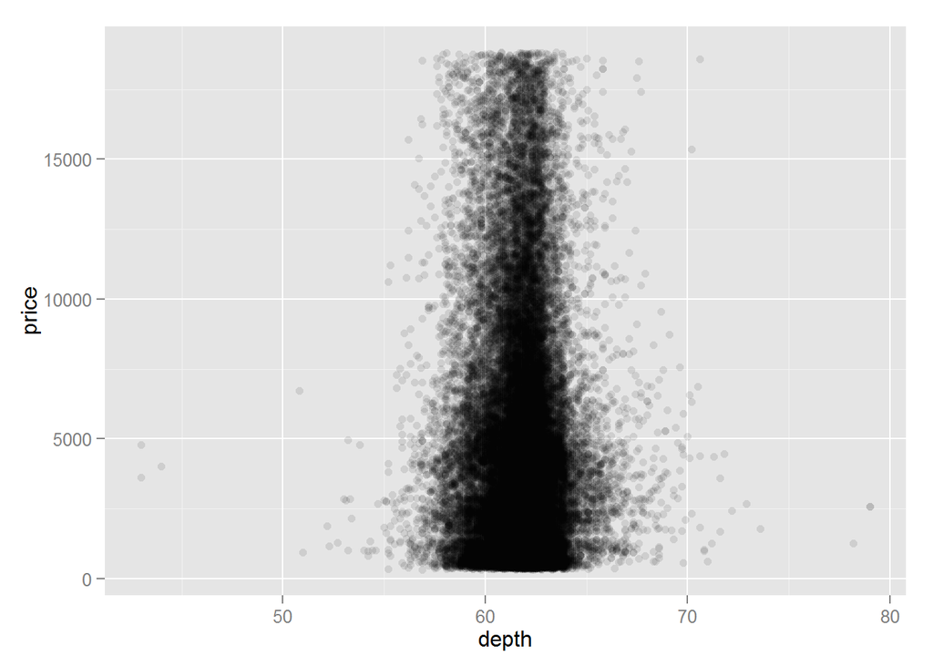

```r
# Create a simple scatter plot of price vs depth.

# This assignment is not graded and
# will be marked as correct when you submit.

# ENTER YOUR CODE BELOW THIS LINE
#==================================================
data(diamonds)
library(ggplot2)
ggplot(aes(x=depth, y=price), data=diamonds) +
  geom_point(alpha=0.1)
```

# Adjustments - price vs. depth

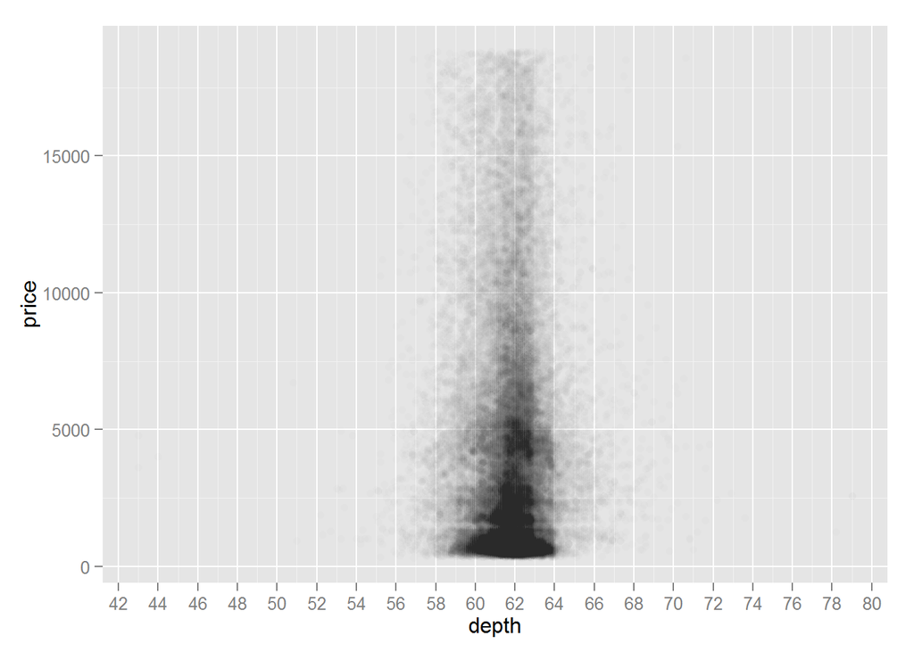

```r
# Change the code to make the transparency of the
# points to be 1/100 of what they are now and mark
# the x-axis every 2 units. See the instructor notes
# for two hints.

# This assignment is not graded and
# will be marked as correct when you submit.

# ALTER THE CODE BELOW THIS LINE
#============================================
data(diamonds)
library(ggplot2)
ggplot(data = diamonds, aes(x = depth, y = price)) +   geom_point(alpha=0.01) +
  scale_x_continuous(breaks = seq(0,80,2))
```

Hint 1: Use the alpha parameter in `geom_point()` to adjust the transparency of points.

Hint 2: Use `scale\_x\_continuous()` with the `breaks` parameter to adjust the x-axis.

# Typical Depth Range

**Most diamonds are between which values?** 60 - 64

# Corellation - depth vs. price

```r
data(diamonds)
library(ggplot2)
cor.test(diamonds$depth, diamonds$price)
```

```
##
##  Pearson's product-moment correlation
##
## data:  diamonds$depth and diamonds$price
## t = -2.473, df = 53938, p-value = 0.0134
## alternative hypothesis: true correlation is not equal to 0
## 95 percent confidence interval:
##  -0.019084756 -0.002208537
## sample estimates:
##        cor
## -0.0106474
```

**What’s the corellation depth vs. price?:** -0.0106474

**Use it to predict the price of the diamond?:** No

**Why?:** No linear correlation - actually increase in variability around 62.

# price vs. carat

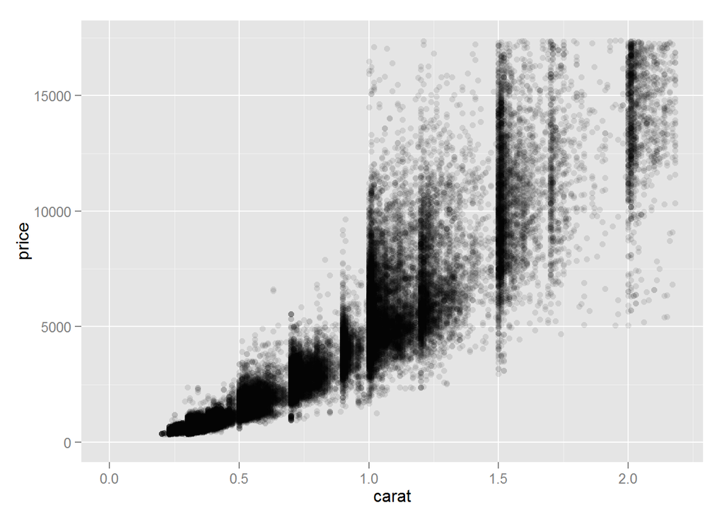

```r
# Create a scatterplot of price vs carat
# and omit the top 1% of price and carat
# values.

# This assignment is not graded and
# will be marked as correct when you submit.

# ENTER YOUR CODE BELOW THIS LINE
# ========================================
data(diamonds)
library(ggplot2)
ggplot(aes(x=carat, y=price), data=diamonds) +
  geom_point(alpha=0.1) +
  xlim(0,quantile(diamonds$carat, 0.99)) +
  ylim(0,quantile(diamonds$price, 0.99))
```

# price vs. volume

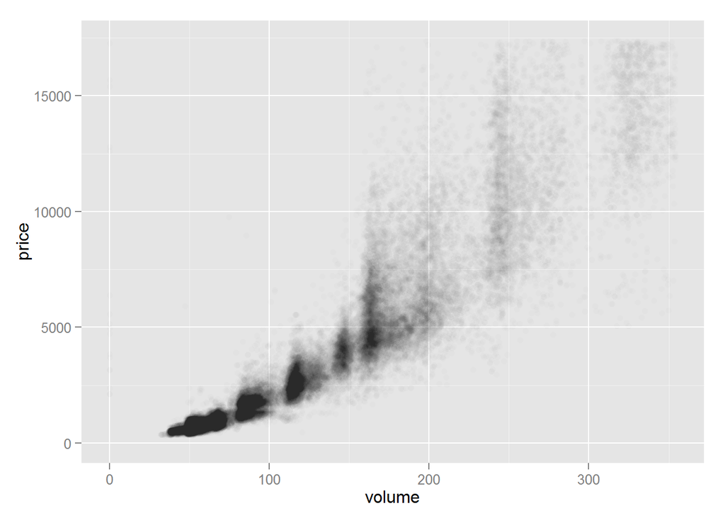

```r
# Create a scatterplot of price vs. volume (x * y * z).
# This is a very rough approximation for a diamond's volume.

# Create a new variable for volume in the diamonds data frame.
# This will be useful in a later exercise.

# Don't make any adjustments to the plot just yet.

# This assignment is not graded and
# will be marked as correct when you submit.

# ENTER YOUR CODE BELOW THIS LINE
# =================================================================
data(diamonds)
library(ggplot2)
diamonds$volume <- diamonds$x * diamonds$y * diamonds$z
ggplot(aes(x=volume, y=price), data=diamonds) +
  geom_point(alpha=0.01) +
  xlim(0,quantile(diamonds$volume, 0.99)) +
  ylim(0,quantile(diamonds$price, 0.99))
```

# Findings: price vs. volume

**Observations?:**

- most values fall in the range of a lower volume
- increased variability in price with higher volume
- generally increased price with increased volume
- some clustering of volumes occurs
- outliers: some volumes are 0!

# Corellations on Subsets

```r
data(diamonds)
library(ggplot2)
diamonds$volume <- diamonds$x * diamonds$y * diamonds$z
diamonds.subset <- subset(diamonds, volume < 800 & volume >= 0)
cor.test(diamonds.subset$price, diamonds.subset$volume)
```

```
##
##  Pearson's product-moment correlation
##
## data:  diamonds.subset$price and diamonds.subset$volume
## t = 551.48, df = 53935, p-value < 2.2e-16
## alternative hypothesis: true correlation is not equal to 0
## 95 percent confidence interval:
##  0.9203320 0.9228746
## sample estimates:
##       cor
## 0.9216132
```

Hint 1: It’s helpful to add a variable for volume to the diamonds data frame. You should exclude diamonds that have a volume greater than or equal to 800. Also, exclude diamonds that have a volume of 0. Use the & symbol between two conditions when you subset the original data frame.

Hint 2: Subset the diamonds data frame under the conditions and save it into another variable. Use that data frame in the cor() function.

# Adjustments - price vs. volume

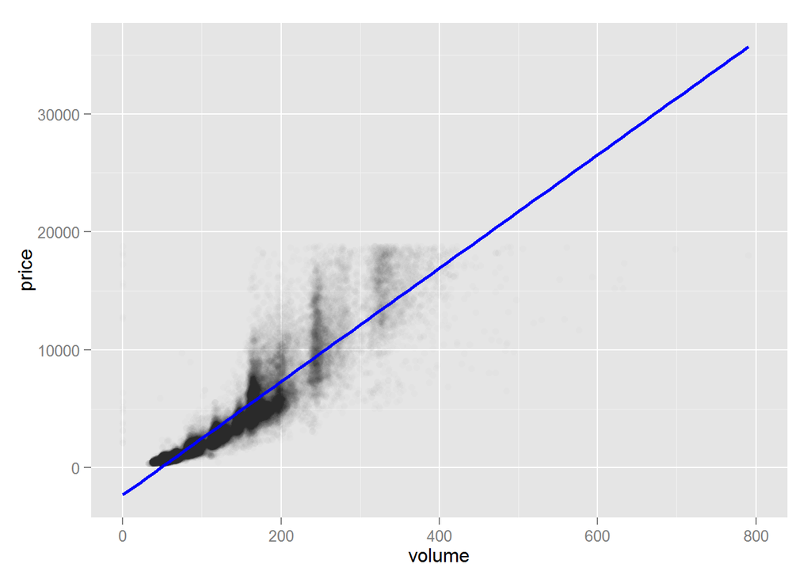

```r
# Subset the data to exclude diamonds with a volume
# greater than or equal to 800. Also, exclude diamonds
# with a volume of 0. Adjust the transparency of the
# points and add a linear model to the plot. (See the
# Instructor Notes or look up the documentation of
# geom_smooth() for more details about smoothers.)

# We encourage you to think about this next question and
# to post your thoughts in the discussion section.

# Do you think this would be a useful model to estimate
# the price of diamonds? Why or why not?

# This assignment is not graded and
# will be marked as correct when you submit.

# ENTER YOUR CODE BELOW THIS LINE
# ========================================

# Prepare Data
data(diamonds)
library(ggplot2)
diamonds$volume <- diamonds$x * diamonds$y * diamonds$z
diamonds.subset <- subset(diamonds, volume < 800 & volume >= 0)

# Make plot
ggplot(aes(x=volume, y=price), data=diamonds.subset) +
  geom_point(alpha=0.01) +
  xlim(0,800) +
  geom_smooth(method="lm", color="blue", size=1)
```

This would not neccessary be a good model since the variability of the price increases with increasing volume.

# Mean Price by Clarity

```r
# Use the function dplyr package
# to create a new data frame containing
# info on diamonds by clarity.

# Name the data frame diamondsByClarity

# The data frame should contain the following
# variables in this order.

#       (1) mean_price
#       (2) median_price
#       (3) min_price
#       (4) max_price
#       (5) n

# where n is the number of diamonds in each
# level of clarity.

# This assignment WILL BE automatically
# graded!

# DO NOT ALTER THE NEXT THREE LINES OF CODE.
# ======================================================
suppressMessages(library(ggplot2))
suppressMessages(library(dplyr))
data(diamonds)

# ENTER YOUR CODE BELOW THIS LINE
# ======================================================
data(diamonds)
diamondsByClarity <- diamonds %>%
  dplyr::group_by(clarity) %>%
  dplyr::summarise(mean_price = mean(price),
        median_price = median(price),
        min_price = min(price),
        max_price = max(price),
        n = n())
```

# Bar Charts of Mean Price

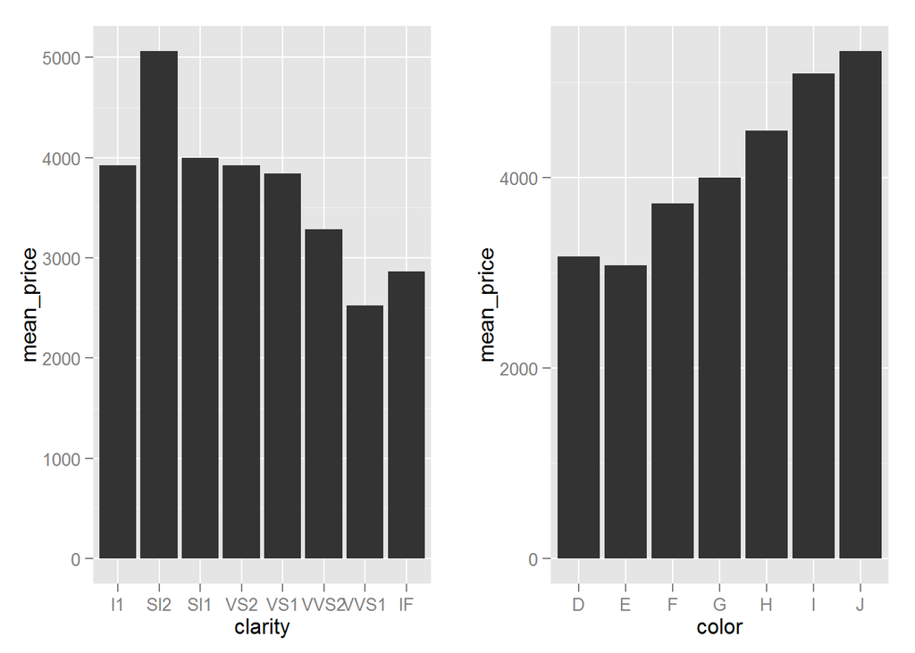

```r
# We’ve created summary data frames with the mean price
# by clarity and color. You can run the code in R to
# verify what data is in the variables diamonds_mp_by_clarity
# and diamonds_mp_by_color.

# Your task is to write additional code to create two bar plots
# on one output image using the grid.arrange() function from the package
# gridExtra.

# This assignment is not graded and
# will be marked as correct when you submit.

# See the Instructor Notes for more info on bar charts
# and for a hint on this task.

# DO NOT DELETE THE LINES OF CODE BELOW
# ===================================================================
data(diamonds)
suppressMessages(library(gridExtra))
suppressMessages(library(ggplot2))
suppressMessages(library(dplyr))

diamonds_by_clarity <- group_by(diamonds, clarity)
diamonds_mp_by_clarity <- summarise(diamonds_by_clarity, mean_price = mean(price))

diamonds_by_color <- group_by(diamonds, color)
diamonds_mp_by_color <- summarise(diamonds_by_color, mean_price = mean(price))

# ENTER YOUR CODE BELOW THIS LINE
# ===================================================================
p1 <- ggplot(data=diamonds_mp_by_clarity, aes(x=clarity, y=mean_price)) + geom_bar(stat="identity")
p2 <- ggplot(data=diamonds_mp_by_color, aes(x=color, y=mean_price)) + geom_bar(stat="identity")
grid.arrange(p1, p2, ncol=2)
```

# Trends in Mean Price

**Observations in each of the bar charts for mean price by clarity and mean price by color?**

- increase in price for colours E->J
- sharp maximum at clarity SI2 and sharp minimum at VVS1 - strange :( - I would assume that price increases as clarity increases

# Gapminder Revisited

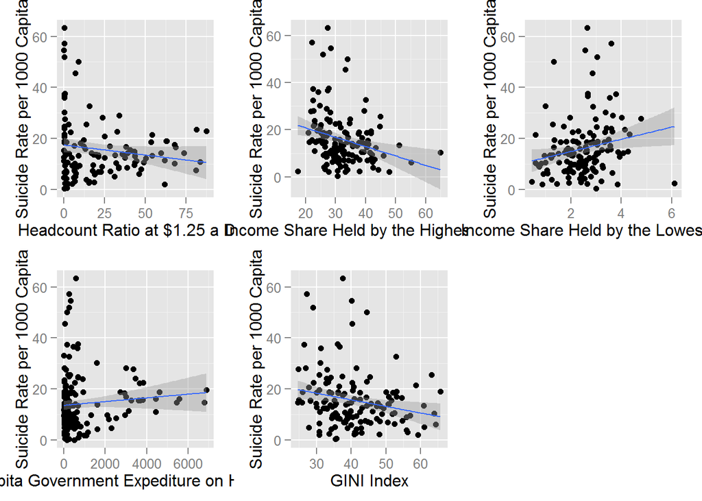

```r
# The Gapminder website contains over 500 data sets with information about
# the world's population. Your task is to continue the investigation you did at the
# end of Problem Set 3 or you can start fresh and choose a different
# data set from Gapminder.

# If you’re feeling adventurous or want to try some data munging see if you can
# find a data set or scrape one from the web.

# In your investigation, examine pairs of variable and create 2-5 plots that make
# use of the techniques from Lesson 4.

# You can find a link to the Gapminder website in the Instructor Notes.

# Once you've completed your investigation, create a post in the discussions that includes:
#       1. the variable(s) you investigated, your observations, and any summary statistics
#       2. snippets of code that created the plots
#       3. links to the images of your plots

# Copy and paste all of the code that you used for
# your investigation, and submit it when you are ready.
# ====================================================================
suppressMessages(library(dplyr))
suppressMessages(library(tidyr))
suppressMessages(library(gridExtra))
setwd('h:/Dokumente/GitHub/2015_Data_Analyst_Project_4/lesson4/')

# Function to read most recent year values from gapminder
read.gapminder.data <- function(filename, v) {
  filedata <- read.csv(filename, header=T, check.names=F)
  filedata <- filedata %>%
    tidyr::gather("Year", "Value", 2:length(filedata)) %>%
    dplyr::filter(!is.na(Value))
  filedata$Year <- as.numeric(levels(filedata$Year))[filedata$Year]
  colnames(filedata)[1] <- "Country"
  tidydata <- filedata %>%
    dplyr::group_by(Country) %>%
    dplyr::summarise(Year=max(Year)) %>%
    dplyr::left_join(filedata, c("Year" = "Year", "Country" = "Country"))
  colnames(tidydata)[2] <- paste(c("Year.", v), collapse="")
  colnames(tidydata)[3] <- v
  return(tidydata)
}

# create huge table
# condition for joining
cc <- c("Country" = "Country")
# read the data and join it all together
mental.health <- suppressWarnings(
    read.gapminder.data("Suicide male indicator file UL 20100916.csv", "SuicideRate") %>%
    dplyr::left_join(read.gapminder.data("20120905_Indicator_Poverty headcount ratio at $1.25 a day (PPP) (% of population).csv", "PovertyRatio125"), cc) %>%
    dplyr::left_join(read.gapminder.data("Indicator_Income share held by highest 10%.csv", "IncomeHighest10P"), cc) %>%
    dplyr::left_join(read.gapminder.data("Indicator_Income share held by lowest 10%.csv", "IncomeLowest10P"), cc) %>%
    dplyr::left_join(read.gapminder.data("indicator_per capita government expenditure on health at average exchange rate (us$).csv", "HealthSpending"), cc) %>%
    dplyr::left_join(read.gapminder.data("indicator SI_POV_GINI.csv", "GINIIndex"), cc)
  )

# draw plots
p1 <- ggplot(data=mental.health, aes(x=PovertyRatio125, y=SuicideRate)) + geom_point() +
  geom_smooth(method="lm") + xlab("Headcount Ratio at $1.25 a Day") + ylab("Suicide Rate per 1000 Capita")
p2 <- ggplot(data=mental.health, aes(x=IncomeHighest10P, y=SuicideRate)) + geom_point() +
  geom_smooth(method="lm") + xlab("Income Share Held by the Highest 10%") + ylab("Suicide Rate per 1000 Capita")
p3 <- ggplot(data=mental.health, aes(x=IncomeLowest10P, y=SuicideRate)) + geom_point() +
  geom_smooth(method="lm") + xlab("Income Share Held by the Lowest 10%") + ylab("Suicide Rate per 1000 Capita")
p4 <- ggplot(data=mental.health, aes(x=HealthSpending, y=SuicideRate)) + geom_point() +
  geom_smooth(method="lm") + xlab("Per Capita Government Expediture on Health (US$)") + ylab("Suicide Rate per 1000 Capita")
p5 <- ggplot(data=mental.health, aes(x=GINIIndex, y=SuicideRate)) + geom_point() +
  geom_smooth(method="lm") + xlab("GINI Index") + ylab("Suicide Rate per 1000 Capita")

# arrange plots
grid.arrange(p1,p2,p3,p4,p5, ncol=3)
```

```r
# summary stats
cor.test(mental.health$SuicideRate, mental.health$PovertyRatio125)
```

```
##
##  Pearson's product-moment correlation
##
## data:  mental.health$SuicideRate and mental.health$PovertyRatio125
## t = -1.7036, df = 120, p-value = 0.09105
## alternative hypothesis: true correlation is not equal to 0
## 95 percent confidence interval:
##  -0.32261598  0.02476989
## sample estimates:
##        cor
## -0.1536677
```

```r
cor.test(mental.health$SuicideRate, mental.health$IncomeHighest10P)
```

```
##
##  Pearson's product-moment correlation
##
## data:  mental.health$SuicideRate and mental.health$IncomeHighest10P
## t = -3.2073, df = 139, p-value = 0.001663
## alternative hypothesis: true correlation is not equal to 0
## 95 percent confidence interval:
##  -0.4100181 -0.1015948
## sample estimates:
##        cor
## -0.2624984
```

```r
cor.test(mental.health$SuicideRate, mental.health$IncomeLowest10P)
```

```
##
##  Pearson's product-moment correlation
##
## data:  mental.health$SuicideRate and mental.health$IncomeLowest10P
## t = 2.3905, df = 139, p-value = 0.01816
## alternative hypothesis: true correlation is not equal to 0
## 95 percent confidence interval:
##  0.03454081 0.35245216
## sample estimates:
##       cor
## 0.1987183
```

```r
cor.test(mental.health$SuicideRate, mental.health$HealthSpending)
```

```
##
##  Pearson's product-moment correlation
##
## data:  mental.health$SuicideRate and mental.health$HealthSpending
## t = 1.1968, df = 179, p-value = 0.233
## alternative hypothesis: true correlation is not equal to 0
## 95 percent confidence interval:
##  -0.05750922  0.23193951
## sample estimates:
##        cor
## 0.08909588
```

```r
cor.test(mental.health$SuicideRate, mental.health$GINIIndex)
```

```
##
##  Pearson's product-moment correlation
##
## data:  mental.health$SuicideRate and mental.health$GINIIndex
## t = -2.6393, df = 143, p-value = 0.009229
## alternative hypothesis: true correlation is not equal to 0
## 95 percent confidence interval:
##  -0.36568647 -0.05442768
## sample estimates:
##        cor
## -0.2155247
```

Material:

- [Strong Relationship beteen Income and Mental Health by Frank Newport](http://www.gallup.com/poll/102883/strong-relationship-between-income-mental-health.aspx)
- [The Prevalence, Distribution, and Mental Health Correlates of Perceived Discrimination in the United States by Roland C. Kessler et al.](http://www.aging.wisc.edu/midus/findings/pdfs/52.pdf)
- [Mental Health And Criminal Justice by Paul E Mullen et al.](http://crg.aic.gov.au/reports/mullen.pdf)

[Gapminder’s Data](http://www.gapminder.org/data/)

- [Inequality index (Gini)](http://spreadsheets.google.com/pub?key=pyj6tScZqmEcjeKHnZq6RIg&output=xls)
- [Income share of the highest 10%](http://spreadsheets.google.com/pub?key=tmKvydPl_roGIQBrMYA6C4g&output=xls)
- [Income share of the lowest 10%](http://spreadsheets.google.com/pub?key=trzLWJQU4SZMDpeVg3XnL5A&output=xls)
- [Extreme Poverty < 125$ per day of 20120905](http://spreadsheets.google.com/pub?key=0ArfEDsV3bBwCdDhjcXdjbURLMFFVcVFPYThhYmtvZXc&output=xls)
- [Government Health Spending](http://spreadsheets.google.com/pub?key=tBwBBkViOJoycBhLnWHqwSQ&output=xls)

[Hans Rosling’s 200 Countries, 200 Years, 4 Minutes](https://www.youtube.com/watch?v=jbkSRLYSojo)

[Save plots using `ggsave`](http://docs.ggplot2.org/current/ggsave.html)